# Gap Credit Spread Strategy — Phase 2 Research Summary

**Author:** Hernan Rosenblum · June 2026 **Universe:** ES · NQ · RTY · YM (CME Globex, continuous futures) **Data:** 7 years · 1-minute OHLCV · 2019–2026 · ~10M bars (Databento) + VIX daily

> *Phase 1 established that overnight gaps ≥ 1×ATR are 97.5 % EOD-safe. The simple credit spread barely captured the edge:* −334 *annual EV at* *0.75×ATR with PT60 exit.*

> **Phase 2 question:** can we extract a tradeable rule from this 97.5 % finding — bounded tail, after-cost positive EV, repeatable?

```
Setup complete.
```

## 1 · Where Phase 1 Left Off — and the Phase 2 Path

Phase 1 confirmed the EOD-safety pattern but the simple structure was EV-negative. Five questions drove Phase 2, each one re-shaping the next:

1. **Does a stop at prev_close fix the losers?** ⟶ No, it cuts winners that recover.
2. **Is there a high-conviction sub-population?** ⟶ Yes — mid-VIX × gap_down.
3. **Do deeper gaps give more credit?** ⟶ No, they give *less* (BS effect).
4. **Should we bet on momentum instead?** ⟶ Yes, but on T2 × gap_up, not T3.
5. **Does any exit rule improve EOD hold?** ⟶ For R1 no; for momentum yes.

## 2 · The Filter That Made the Strategy Tradeable

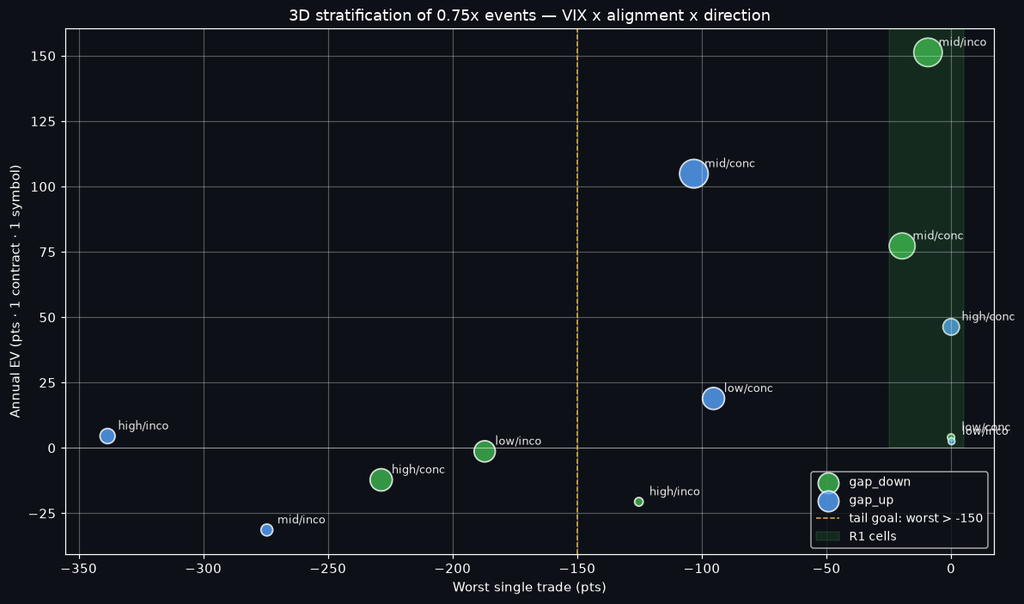

**Reading the chart.** Each bubble is a (VIX × alignment × direction) cell; size is trades per year, position is (worst trade, annual EV). The cells **clustered top-right** are what we want — positive EV, bounded worst case. Two stand out cleanly: `mid/concurrent/gap_down` and `mid/incongruent/gap_down`. Together they form **Rule R1**.

| Unfiltered NS·EOD at 0.75×ATR | After R1 filter |
| --- | --- |
| 88 trades/yr | 28.7 trades/yr |
| +347 annual EV | +228 annual EV |
| Worst trade −338 pts | **Worst trade −19.6 pts** |

Lost 1/3 of EV — cut tail by **17×**. Risk-adjusted return improved dramatically because losers per cell are bounded by `width − credit`, and filtering on VIX caps the spread width via ATR.

## 3 · Counterintuitive — Deeper Gaps Are Not Better

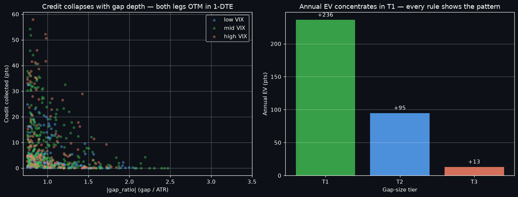

| Tier | Avg credit | Annual EV (% of total) |
| --- | --- | --- |
| **T1** [0.75 – 1.0 × ATR] | 10.7 | **236 (69%)** |
| T2 [1.0 – 1.5 × ATR] | 5.7 | 95 (28%) |
| T3 [1.5 + × ATR] | 1.6 | 13 (4 %) |

At deeper gaps, **both spread legs move OTM together** in a 1-DTE option. Premium drops off as a Gaussian function of strike distance, so the difference (= credit) shrinks faster than either leg.

In real markets put-side skew makes this worse: the OTM long leg trades at elevated IV vs constant-vol BS, further compressing the credit. **The T1-dominance is structural, not a model artifact.**

## 4 · A Second Edge — Momentum on T2 × gap_up

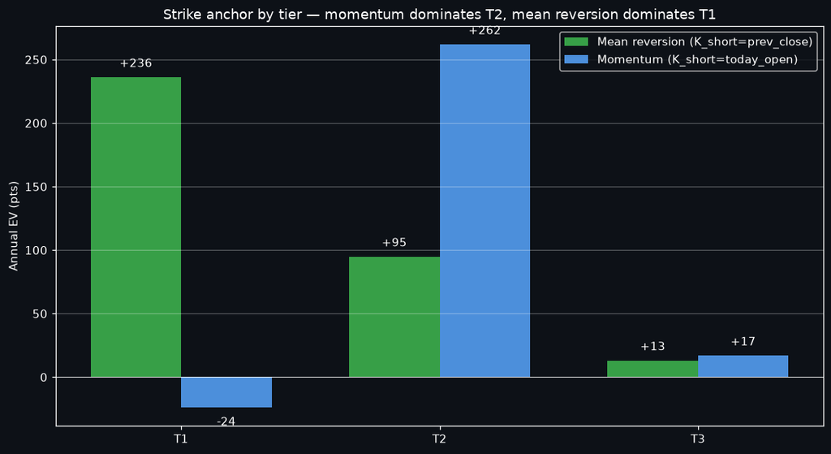

**Mean-reversion structure** (K_short = yesterday's close) wins on T1. **Momentum structure** (K_short = today's open) wins on T2.

The two edges are non-overlapping — different gap tier, different direction:

- **R1** trades T1 × gap_down (fear reversion)
- **M1** trades T2 × gap_up (greed extension)

T3 (deepest gaps) doesn't carry either edge — gap-hold rate falls to ~44 % because the move is "exhausted" by the open. Marginal participants by 09:30 are the contrarians.

## 5 · Exit Rules — Why EOD Wins for R1 but SS Wins for Momentum

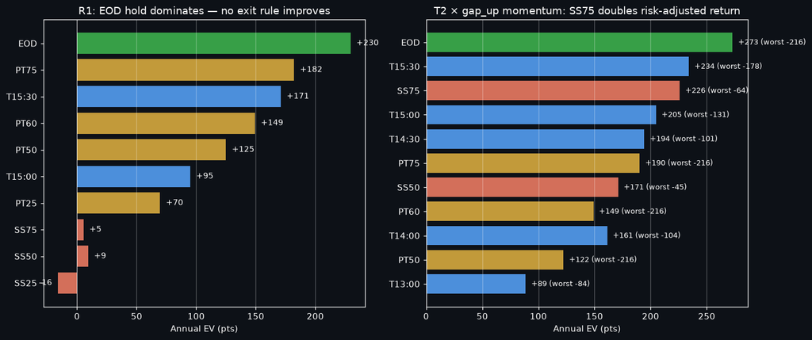

The asymmetry is structural:

[output not shown]

R1 doesn't need a stop — most "adverse" moves are noise that mean-reverts. M1 does — ATM gamma escalates losers fast, and a SS75 exit (close on a 75 %-of-width adverse move) captures the worst trades *before* they hit max loss. Risk-adjusted return on M1 jumps from 1.26 to 3.56 with SS75 alone.

## 6 · The Two Final Rules

### R1 — Mean Reversion (primary)

```
Universe:    ES, NQ, RTY, YM
Trigger:     Overnight |gap| / ATR(14) ≥ 0.75
Direction:   gap_down only
Regime:      VIX(prev close) ∈ [15, 25)
Structure:   1-DTE bear call spread
             K_short = prev_close
             K_long  = prev_close + 0.5 × ATR(14)
Entry:       09:30 ET
Exit:        16:00 ET (HOLD TO CLOSE)
```

| Metric | Value |
| --- | --- |
| Events / yr | **28.7** |
| Annual EV | **+228 pts** |
| EV / trade | +7.96 pts |
| Win rate | 93.5 % |
| Worst trade | **−19.6 pts** |
| Avg credit | 8.6 pts |

### M1 — Momentum (secondary)

```
Universe:    ES, NQ, RTY, YM
Trigger:     Overnight 1.0 ≤ |gap| / ATR(14) < 1.5
Direction:   gap_up only
Regime:      no VIX filter
Structure:   1-DTE bull put spread anchored at OPEN
             K_short = today_open
             K_long  = today_open − 0.5 × ATR(14)
Entry:       09:30 ET
Exit:        SS75 — close if low <= today_open − 0.75 × spread_width
             else 16:00 ET
```

| Metric | Value |
| --- | --- |
| Events / yr | **11.6** |
| Annual EV | **+226 pts** |
| EV / trade | +19.5 pts |
| Win rate | 56 % (after SS75) |
| Worst trade | **−63.5 pts** |
| Avg credit | 44.2 pts |

## 7 · Combined Portfolio

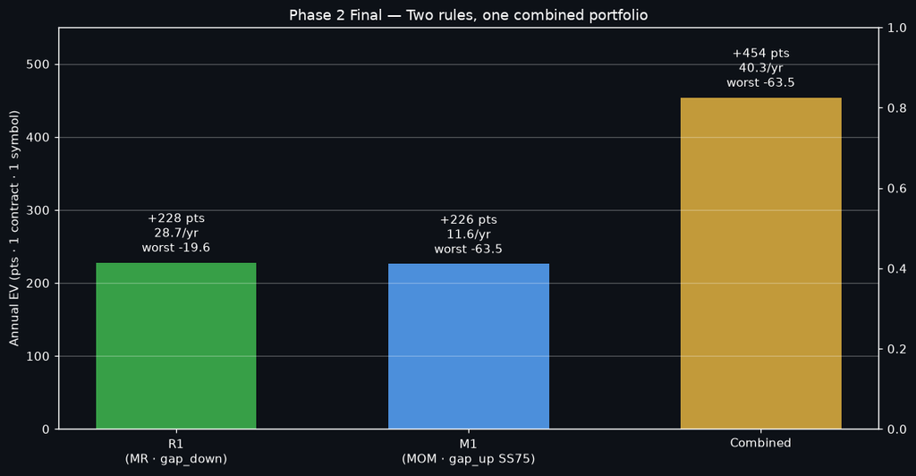

R1 and M1 are **non-overlapping**: R1 fires on gap_down days, M1 on gap_up. They cluster on macro signal days but never on the same trade. Combined:

| Combined R1 + M1 | Value |
| --- | --- |
| Signals / yr | **40.3** |
| Annual EV | **+454 pts** |
| Worst single trade | **−63.5 pts** (M1) |

For ES at $50/pt and 1-contract-per-symbol-per-rule sizing:

- Annual EV ≈ **$22,700 / year / symbol**
- Worst single-day loss ≈ **$3,175** (from M1)

Per-symbol position sizing should differ between rules because the worst-trade ratio is ~3×.

## 8 · Limitations & Open Questions

### Modeling caveats

- All EV in **BS-model points** with constant-vol σ = VIX/100. Real put skew inflates the OTM long-leg cost — credit estimates are slightly optimistic.
- No slippage or commissions. Realistic mid-fill on a 5-point-wide ES spread is 0.5–1.0 pt round trip. At R1's 8.6-pt avg credit, slippage erodes ~10–15 % of EV. M1's 44-pt credit is more robust to slippage.
- 1-DTE assumption matches 0-DTE / 1-DTE ES, SPX-style options. Index-future options have specific expirations; in live trading, the nearest weekly is the appropriate proxy.

### Statistical caveats

- 7-year sample. Includes 2020 COVID volatility and 2022 inflation regime. A pre-2008 / 1998-crisis regime is **not** in this sample.
- Survivorship in 4-symbol universe — all are major liquid index futures.
- Cluster risk: 4 symbols all gap on the same macro days; treat as roughly one signal with leveraged contract sizing, not 4 independent signals.

### What Phase 3 should ask

1. **Skew-aware repricing.** Pull empirical IV skew (from CBOE or simulated) and recompute R1 / M1 credit. Likely reduces EV ~10–20 %.
2. **Slippage stress test.** Subtract 0.5 / 1.0 / 2.0 pt slippage per trade.
3. **Live forward test.** Paper trade R1 + M1 from 2026-07-01 for one quarter using the locked specs in §6. Verify hit-rate matches.
4. **Hedged variants.** Buy a deep OTM long option to cap M1 tail from −63 to ~−20 at a cost of ~1 pt credit. Worth modeling.
5. **Position sizing.** Risk-budget per rule based on the worst-trade ratio. R1 can size 3× larger than M1 for equal max-drawdown exposure.

### What was NOT a viable rule

- Hard stops at prev_close (Task 8) — cuts winners that recover
- Deep-gap rules (T3) — gaps are exhausted by open, no momentum
- PT60 exit on R1 (Task 11) — caps winners without saving losers